# MR Signal Equations

## Gradient Echo

The key parameters for the sequence are the flip angle , TR, TE, T1 and T2*. The formula is

$$Signal(GE) = M_0 {\frac{sin(\alpha) (1 - exp^{(-TR/{T_1})} )e^{(-TE/{T_2}^*)}}{1 - cos(\alpha)(1 - exp^{-(TR/{T_1})})}$$

[output not shown]

## Calculating the GE signal

We can write the parameters and Matlab expression this way

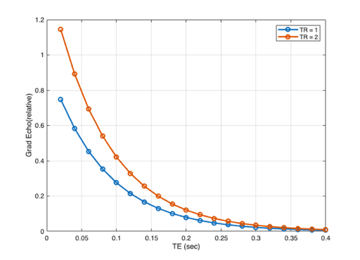

```matlab
FA = 60;     % deg
T2star = 0.08;  % sec

% Sweep out a set of measurement times for the graident echo
TE = (0.02:0.02:0.40);  % 20 ms to 400 msec

% sind is sine for degree inputs
% The Gradient Echo Signal Equation
TR = 1;
sig = mrSignalEquations('gradient echo',...
    'FA',FA,'TE',TE, 'TR',TR, ...
    'T1',wT1,'T2star',wT2star);

mrvNewGraphWin;
plot(TE,sig,'-o','Linewidth',2);
grid on;
xlabel('TE (sec)'); ylabel('Grad Echo(relative)');

hold on;
TR = 2;
sig = mrSignalEquations('gradient echo',...
    'FA',FA,'TE',TE, 'TR',TR, ...
    'T1',wT1,'T2star',wT2star);
plot(TE,sig,'-o','Linewidth',2);
legend({'TR = 1','TR = 2'})

% Pulse sequence parameters
% In a pair of experiments I am analyzing, we used two different Gradient Echo
% (GE) pulse sequences.  Here are the two sets of parameters.
%
% *Gradient Echo sequence parameters*
%
% $$\matrix{\mathbf{Sequence}    	&  \mathbf{TE (s)}	& \mathbf{TR (s)}	& \mathbf{FA
% (deg)}   \cr\hline\mathbf{Resting}		& 0.028 			& 2.00	        & 77	\cr\mathbf{SMS}
% & 0.0116	  	        & 0.25        & 48	\cr}$$
%
% Set the pulse sequence parameters for resting and sms methods.

% Resting Sequence parameters
rTE = 0.0275; rFA = 77; rTR = 2;

% SMS sequence parameters
sTE = 0.011; sFA = 48; sTR = 0.25;
```

Calculate signal ratios for the gray matter and the two sequences

```matlab
meanGRSig = mrSignalEquations('gradient echo',...
    'FA',rFA,'TE',rTE, 'TR',rTR, ...
    'T1',gT1,'T2star',gT2star)

% SMS
meanGSSig = mrSignalEquations('gradient echo',...
    'FA',sFA,'TE',sTE, 'TR',sTR, ...
    'T1',gT1,'T2star',gT2star)

fprintf('Gray matter mean signal ratio (GE/SMS) %f\n',meanGRSig/meanGSSig);
```

```
meanGRSig =

    0.7529


meanGSSig =

    0.1447

Gray matter mean signal ratio (GE/SMS) 5.204428
```

Now for the white matter

```matlab
% The Gradient Echo Signal Equation for white matter, resting state
meanWRrSig = mrSignalEquations('gradient echo',...
    'FA',rFA,'TE',rTE, 'TR',rTR, ...
    'T1',wT1,'T2star',wT2star);

% SMS
meanWSSig = mrSignalEquations('gradient echo',...
    'FA',sFA,'TE',sTE, 'TR',sTR, ...
    'T1',wT1,'T2star',wT2star);

% Ratios of the absolute mean signals
fprintf('White matter mean signal ratio (GE/SMS) %f\n',meanWRrSig/meanWSSig);

% Impact of tissue parameter changes
% When there is more or less blood in a voxel, we expect the T1 to change.
% What happens to the signal if T1 changes? In this case, we are measuring the
% contrast, not the absolute signal level.
%
% So let's see how much the signal changes when T1 changes.  It seems a bigger
% change in SMS than resting

wT1new = wT1 + 0.1;

% Resting state
geT1SensitivityW = mrSignalEquations('gradient echo',...
    'FA',rFA,'TE',rTE, 'TR',rTR, ...
    'T1',wT1new,'T2star',wT2star) / meanWRrSig;

% SMS - contrast
smsT1SensitivityW = mrSignalEquations('gradient echo',...
    'FA',sFA,'TE',sTE, 'TR',sTR, ...
    'T1',wT1new,'T2star',wT2star)  / meanWSSig;

fprintf('White T1 sensitivity (100 ms):  GE %f  ;  SMS %f',geT1SensitivityW,smsT1SensitivityW);
```

```
White matter mean signal ratio (GE/SMS) 3.772262
White T1 sensitivity (100 ms):  GE 0.964183  ;  SMS 0.885026
```

What about if T2* changes? A small change in SMS, but a larger change in resting

```matlab
wT2starnew = wT2star + 0.005;

% Resting
geT2starSensitivityW = mrSignalEquations('gradient echo',...
    'FA',rFA,'TE',rTE, 'TR',rTR, ...
    'T1',wT1,'T2star',wT2starnew)  / meanWRrSig;

% SMS
smsT2starSensitivityW = mrSignalEquations('gradient echo',...
    'FA',sFA,'TE',sTE, 'TR',sTR, ...
    'T1',wT1,'T2star',wT2starnew) / meanWSSig;

fprintf('White T2* sensitivity (5 ms):  GE %f  ;  SMS %f',geT2starSensitivityW,smsT2starSensitivityW);
```

```
White T2* sensitivity (5 ms):  GE 1.020426  ;  SMS 1.008121
```

Now for gray matter and T1

```matlab
gT1new = gT1 + 0.1;

% Resting state
geT1SensitivityG = mrSignalEquations('gradient echo',...
    'FA',rFA,'TE',rTE, 'TR',rTR, ...
    'T1',gT1new,'T2star',gT2star)   / meanGRSig;

% SMS - contrast
smsT1SensitivityG = mrSignalEquations('gradient echo',...
    'FA',sFA,'TE',sTE, 'TR',sTR, ...
    'T1',gT1new,'T2star',gT2star) / meanGSSig;

fprintf('Gray T1 sensitivity (100 ms):  GE %f  ;  SMS %f',geT1SensitivityG,smsT1SensitivityG);
```

```
Gray T1 sensitivity (100 ms):  GE 0.961315  ;  SMS 0.921007
```

Now for gray matter and T2*

```matlab
gT2starnew = gT2star + 0.005;

% Resting
geT2starSensitivityG = mrSignalEquations('gradient echo',...
    'FA',rFA,'TE',rTE, 'TR',rTR, ...
    'T1',gT1,'T2star',gT2starnew)   / meanGRSig;

% SMS
smsT2starSensitivityG = mrSignalEquations('gradient echo',...
    'FA',sFA,'TE',sTE, 'TR',sTR, ...
    'T1',gT1,'T2star',gT2starnew)   / meanGSSig;

fprintf('Gray T2* sensitivity (5 ms):  GE %f ; SMS %f',geT2starSensitivityG,smsT2starSensitivityG);
```

```
Gray T2* sensitivity (5 ms):  GE 1.010929 ; SMS 1.004357
```

[Published with MATLAB® R2026a](https://www.mathworks.com/products/matlab/)